# outcome-informed-analysis

## Outcome Informed Analysis

This analysis is done after peeking at the learning outcomes.

Outcomes:

- Develop students’ globalized perspectives in their learning
- Promote understanding through interdisciplinary lenses with which to examine pertinent world issues
- Develop cultural awareness, interculturality, growth required for communication (scientific and otherwise) and engagement

Discussion 1: Consider the impact of the global COVID pandemic on learning and education in general.

- Identifying similarities and differences encountered in Iraq and US relating to the pandemic's impact on education and learning, and considered any cultural, discipline, and language factors that might have played a role.
- Developing understanding from the group's discussion that contributed to any aspect of their cultural understanding and growth.

Discussion 2: Consider issues that present as gender-related inequities or challenges facing individuals pursuing their education and/or career/professional development.

- Identifying commonalities/differences relating to these gender issues and the factors that contribute to them, comparing across US and Iraq contexts (specifically, cultural, discipline/field of study, and language factors that might play a role in promoting/reducing gender-related inequities or challenges to education and career opportunities).
- Developing understanding from the group's discussion that contributed to any aspect of their cultural understanding and growth.

Discussion 3: Critically reflect on the advantages and/or disadvantages of having 'English-only' as the language of communication (both verbal and written) in this COIL experience and any other academic initiatives.

- Developing understanding from the group's discussion and what contributed to language awareness and intercultural understanding (specifically issues related to the use of English as a lingua franca, and as a communication tool for speakers of diverse linguacultural backgrounds).
- Developing awareness of any issues of misunderstanding and communication difficulties related to English practice experienced in from their COIL participation.

### Setup

We import the `coilnlp` package and load in pre-processed dataframes. Note that `numpy`, `pandas`, and `matplotlib.pyplot` have already been imported as `np`, `pd`, and `plt`, respectively.

```python
import warnings
warnings.filterwarnings("ignore")
```

```python
from coilnlp import *
```

```python
# sentences
covid = pd.read_csv('covid-sent.csv', header = 0)
gender = pd.read_csv('gender-sent.csv', header = 0)
english = pd.read_csv('english-sent.csv', header = 0)
sent = pd.concat([covid, gender, english], ignore_index = True)
sent.tail()
```

|  | TOPIC | STATE | DOCNUM | SENTENCE |
| --- | --- | --- | --- | --- |
| 991 | english | us | 9 | many jobs will even consider hiring an applic... |
| 992 | english | us | 9 | our group all agreed as individuals who have ... |
| 993 | english | us | 9 | english has become an added benefit to know i... |
| 994 | english | us | 9 | once you can overcome some of the beginning i... |
| 995 | english | us | 9 | NaN |

```python
# documents
covid = pd.read_csv('covid-docs.csv', header = 0)
gender = pd.read_csv('gender-docs.csv', header = 0)
english = pd.read_csv('english-docs.csv', header = 0)
docs = pd.concat([covid, gender, english], ignore_index = True)
docs.head()
```

|  | TOPIC | STATE | DOCNUM | TEXT |
| --- | --- | --- | --- | --- |
| 0 | covid | iq | 1 | the covid 19 pandemic has transformed the cont... |
| 1 | covid | iq | 10 | well today me and my group talked about covid ... |
| 2 | covid | iq | 11 | it was an interesting conversation with my par... |
| 3 | covid | iq | 12 | in the educational process covid 19 changes ev... |
| 4 | covid | iq | 13 | okay in our group discussion meeting today we ... |

### Word Clouds

```
United States (All)
```

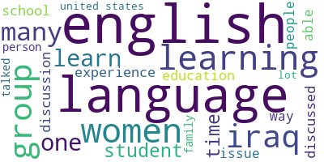

```python
print('United States (All)')
make_word_cloud(docs[docs['STATE'] == 'us']).to_image()
```

```
Iraq (All)
```

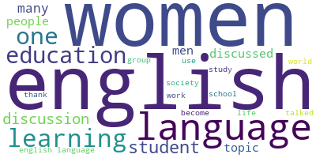

```python
print('Iraq (All)')
make_word_cloud(docs[docs['STATE'] == 'iq']).to_image()
```

Juxtaposing these word clouds, we identify some interesting words. For the US students, iraq, experience, united states, and family. For the IQ students, world, work, society, and thank.

```
United States (COVID-19)
```

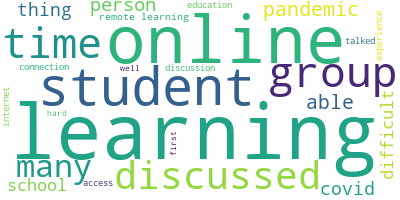

```python
print('United States (COVID-19)')
make_word_cloud(docs[(docs['STATE'] == 'us') & (docs['TOPIC'] == 'covid')]).to_image()
```

```
Iraq (COVID-19)
```

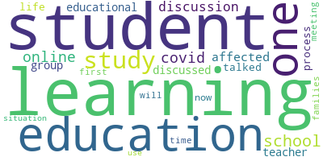

```python
print('Iraq (COVID-19)')
make_word_cloud(docs[(docs['STATE'] == 'iq') & (docs['TOPIC'] == 'covid')]).to_image()
```

```
United States (Gender)
```

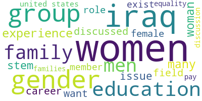

```python
print('United States (Gender)')
make_word_cloud(docs[(docs['STATE'] == 'us') & (docs['TOPIC'] == 'gender')]).to_image()
```

```
Iraq (Gender)
```

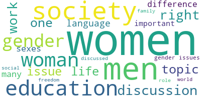

```python
print('Iraq (Gender)')
make_word_cloud(docs[(docs['STATE'] == 'iq') & (docs['TOPIC'] == 'gender')]).to_image()
```

```
United States (English)
```

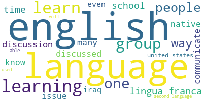

```python
print('United States (English)')
make_word_cloud(docs[(docs['STATE'] == 'us') & (docs['TOPIC'] == 'english')]).to_image()
```

```
Iraq (English)
```

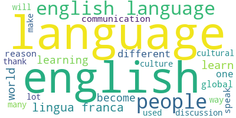

```python
print('Iraq (English)')
make_word_cloud(docs[(docs['STATE'] == 'iq') & (docs['TOPIC'] == 'english')]).to_image()
```

Given the word abundances, the learning objectives, and the words already identified in the non-informed analysis, we want to study further english, language, communication, lingua, and learn. These words are abundant in both groups.

### Sentences

```python
words = [
    'united states', ' us ', 'experie', 'thank',
    'english', 'language', 'communicat', 'lingua',
    'learn', 'men', 'man', 'gender', 'sex', 'role',
    'student', 'study', 'pandemic', 'covid', 'iraq'
]
```

```python
# saving
import re
for word in words:
    with open('searches/' + word + '-iq-gender.txt', 'w') as f:
        for tup in set(find_word_in_sentences(word, sent[(sent['TOPIC'] == 'gender') & (sent['STATE'] == 'iq')])):
            f.write('Topic : ' + tup[0]); f.write('\n')
            f.write('State : ' + tup[1]); f.write('\n')
            f.write('DocID : ' + str(tup[2])); f.write('\n')
            f.write('Text : ' + re.sub(r'\.', '.\n', tup[5])); f.write('\n')
            f.write('\n')
    with open('searches/' + word + '-us-gender.txt', 'w') as f:
        for tup in set(find_word_in_sentences(word, sent[(sent['TOPIC'] == 'gender') & (sent['STATE'] == 'us')])):
            f.write('Topic : ' + tup[0]); f.write('\n')
            f.write('State : ' + tup[1]); f.write('\n')
            f.write('DocID : ' + str(tup[2])); f.write('\n')
            f.write('Text : ' + re.sub(r'\.', '.\n', tup[5])); f.write('\n')
            f.write('\n')
    with open('searches/' + word + '-iq-covid.txt', 'w') as f:
        for tup in set(find_word_in_sentences(word, sent[(sent['TOPIC'] == 'covid') & (sent['STATE'] == 'iq')])):
            f.write('Topic : ' + tup[0]); f.write('\n')
            f.write('State : ' + tup[1]); f.write('\n')
            f.write('DocID : ' + str(tup[2])); f.write('\n')
            f.write('Text : ' + re.sub(r'\.', '.\n', tup[5])); f.write('\n')
            f.write('\n')
    with open('searches/' + word + '-us-covid.txt', 'w') as f:
        for tup in set(find_word_in_sentences(word, sent[(sent['TOPIC'] == 'covid') & (sent['STATE'] == 'us')])):
            f.write('Topic : ' + tup[0]); f.write('\n')
            f.write('State : ' + tup[1]); f.write('\n')
            f.write('DocID : ' + str(tup[2])); f.write('\n')
            f.write('Text : ' + re.sub(r'\.', '.\n', tup[5])); f.write('\n')
            f.write('\n')
    with open('searches/' + word + '-iq-english.txt', 'w') as f:
        for tup in set(find_word_in_sentences(word, sent[(sent['TOPIC'] == 'english') & (sent['STATE'] == 'iq')])):
            f.write('Topic : ' + tup[0]); f.write('\n')
            f.write('State : ' + tup[1]); f.write('\n')
            f.write('DocID : ' + str(tup[2])); f.write('\n')
            f.write('Text : ' + re.sub(r'\.', '.\n', tup[5])); f.write('\n')
            f.write('\n')
    with open('searches/' + word + '-us-english.txt', 'w') as f:
        for tup in set(find_word_in_sentences(word, sent[(sent['TOPIC'] == 'english') & (sent['STATE'] == 'us')])):
            f.write('Topic : ' + tup[0]); f.write('\n')
            f.write('State : ' + tup[1]); f.write('\n')
            f.write('DocID : ' + str(tup[2])); f.write('\n')
            f.write('Text : ' + re.sub(r'\.', '.\n', tup[5])); f.write('\n')
            f.write('\n')
```

### End of Notebook

To close, we use the package `coilnlp` to search for sentences containing words that have interesting statistical behavior for the given dataset and research problem. Please review the saved text files to make interpretations and conclusions.